# Task2_Clustering

EMMADISHETTI TEJASWI

16/02/2021

# Prediction using Unsupervised Machine Learning

# GRIP @ The Sparks Foundation

# Objective: The task is to predict the optimum number of clusters and represent it visually from the given ‘Iris’ dataset,

```r
#setting my working directory
setwd("C:/Users/EMMADISHETTI TEJASWI/Desktop/tsf")
#Importing Dataset
iris<- read.csv("Iris.csv",header=TRUE)
iris<-iris[2:6]
```

# Exploring the data

```r
str(iris)
```

```
## 'data.frame':    150 obs. of  5 variables:
##  $ SepalLengthCm: num  5.1 4.9 4.7 4.6 5 5.4 4.6 5 4.4 4.9 ...
##  $ SepalWidthCm : num  3.5 3 3.2 3.1 3.6 3.9 3.4 3.4 2.9 3.1 ...
##  $ PetalLengthCm: num  1.4 1.4 1.3 1.5 1.4 1.7 1.4 1.5 1.4 1.5 ...
##  $ PetalWidthCm : num  0.2 0.2 0.2 0.2 0.2 0.4 0.3 0.2 0.2 0.1 ...
##  $ Species      : chr  "Iris-setosa" "Iris-setosa" "Iris-setosa" "Iris-setosa" ...
```

```r
summary(iris)
```

```
##  SepalLengthCm    SepalWidthCm   PetalLengthCm    PetalWidthCm
##  Min.   :4.300   Min.   :2.000   Min.   :1.000   Min.   :0.100
##  1st Qu.:5.100   1st Qu.:2.800   1st Qu.:1.600   1st Qu.:0.300
##  Median :5.800   Median :3.000   Median :4.350   Median :1.300
##  Mean   :5.843   Mean   :3.054   Mean   :3.759   Mean   :1.199
##  3rd Qu.:6.400   3rd Qu.:3.300   3rd Qu.:5.100   3rd Qu.:1.800
##  Max.   :7.900   Max.   :4.400   Max.   :6.900   Max.   :2.500
##    Species
##  Length:150
##  Class :character
##  Mode  :character
##
##
##
```

# Data Preprocessing for Clustering

```r
iris.s<-iris
iris.s$Species<-NULL
```

## A short note on Within Cluster Sum of Squares

#It states that while clustering performance as measured by WCSS increases (i.e. WCSS decreases) with increase in k, rate of increase is usually decreasing.So performance improvement for increasing number of cluster from, say, 3 to 4 is higher than that for increasing from 4 to 5. Plotting WCSS against increasing k can show an ‘elbow’ which demarks significant drop in rate of increase. Selecting number of clusters corresponding to elbow point achieves reasonable performance without having too many clusters. This is still judgmental since what constitutes elbow is visually determined. Further, in practice, there may not be an elbow but smooth curve, or, there may be more than one elbow.Using the elbow method to find the optimal number of clusters

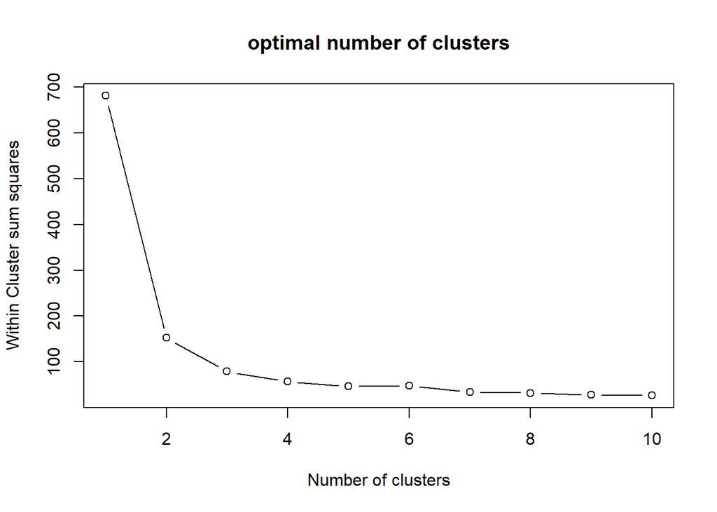

```r
set.seed(6)
wcss<-vector()
for (i in 1:10)
{
  wcss[i]<-sum(kmeans(iris.s,i)$withinss)
}
plot(1:10,wcss,type="b",xlab="Number of clusters",ylab="Within Cluster sum squares",main="optimal number of clusters")
```

# As we observe above through the elbow method we find that the optimum value of the elbow lies at x=3 and hence we choose our number of clusters to be 3.

```r
set.seed(56)
result=kmeans(iris.s,3,iter.max=300,nstar=10)
result
```

```
## K-means clustering with 3 clusters of sizes 50, 62, 38
##
## Cluster means:
##   SepalLengthCm SepalWidthCm PetalLengthCm PetalWidthCm
## 1      5.006000     3.418000      1.464000     0.244000
## 2      5.901613     2.748387      4.393548     1.433871
## 3      6.850000     3.073684      5.742105     2.071053
##
## Clustering vector:
##   [1] 1 1 1 1 1 1 1 1 1 1 1 1 1 1 1 1 1 1 1 1 1 1 1 1 1 1 1 1 1 1 1 1 1 1 1 1 1
##  [38] 1 1 1 1 1 1 1 1 1 1 1 1 1 2 2 3 2 2 2 2 2 2 2 2 2 2 2 2 2 2 2 2 2 2 2 2 2
##  [75] 2 2 2 3 2 2 2 2 2 2 2 2 2 2 2 2 2 2 2 2 2 2 2 2 2 2 3 2 3 3 3 3 2 3 3 3 3
## [112] 3 3 2 2 3 3 3 3 2 3 2 3 2 3 3 2 2 3 3 3 3 3 2 3 3 3 3 2 3 3 3 2 3 3 3 2 3
## [149] 3 2
##
## Within cluster sum of squares by cluster:
## [1] 15.24040 39.82097 23.87947
##  (between_SS / total_SS =  88.4 %)
##
## Available components:
##
## [1] "cluster"      "centers"      "totss"        "withinss"     "tot.withinss"
## [6] "betweenss"    "size"         "iter"         "ifault"
```

# compare the clusters with the species

```r
table(iris$Species,result$cluster)
```

```
##
##                    1  2  3
##   Iris-setosa     50  0  0
##   Iris-versicolor  0 48  2
##   Iris-virginica   0 14 36
```

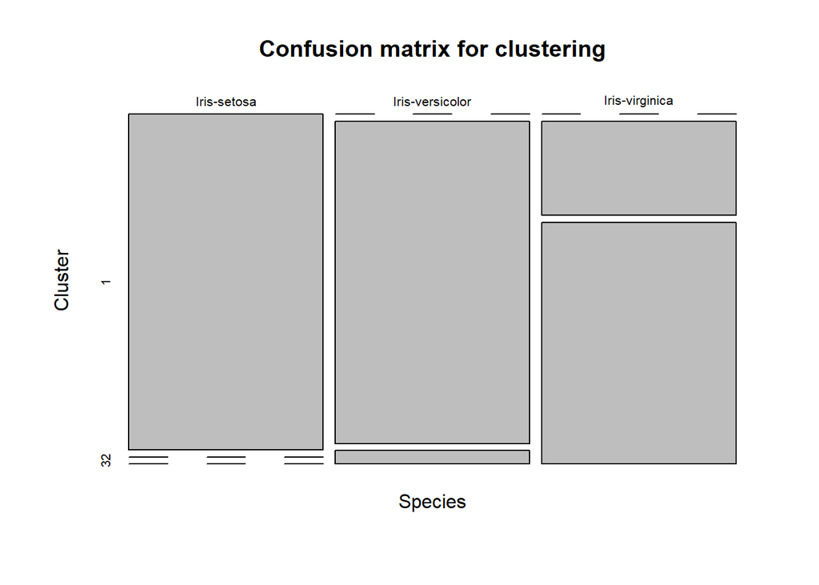

```r
plot(table(iris$Species,result$cluster),main="Confusion matrix for clustering",xlab="Species",ylab="Cluster")
```

# Visualizing the clusters

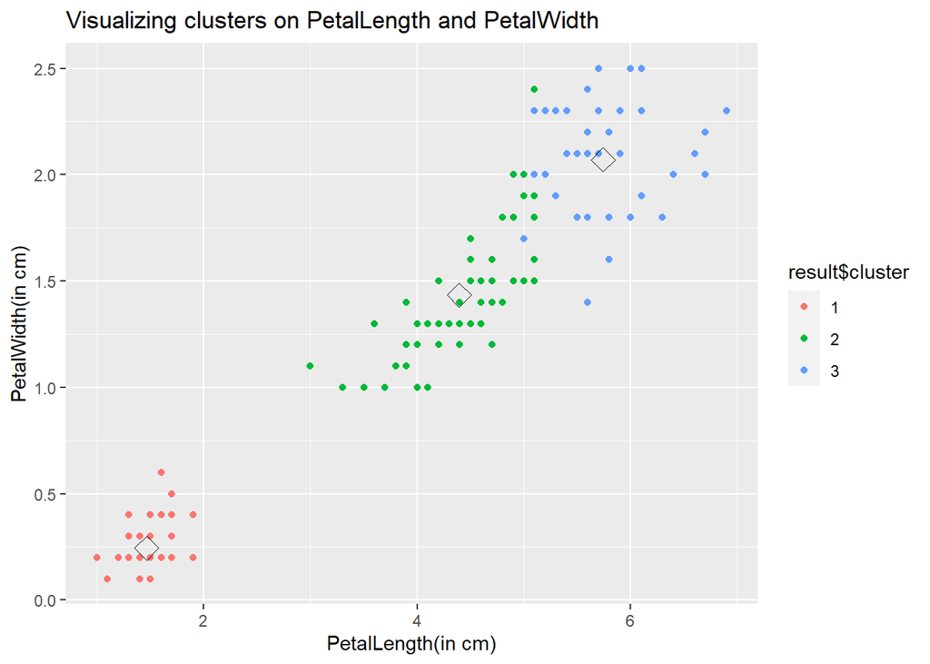

```r
library(ggplot2)
result$cluster=as.factor(result$cluster)
center=data.frame(result$centers)
ggplot(iris.s)+geom_point(aes(x=PetalLengthCm,y=PetalWidthCm,color=result$cluster))+geom_point(data=center,aes(x=PetalLengthCm,y=PetalWidthCm),shape=5,color="black",size=4)+labs(x="PetalLength(in cm)",y="PetalWidth(in cm)")+ggtitle("Visualizing clusters on PetalLength and PetalWidth")
```

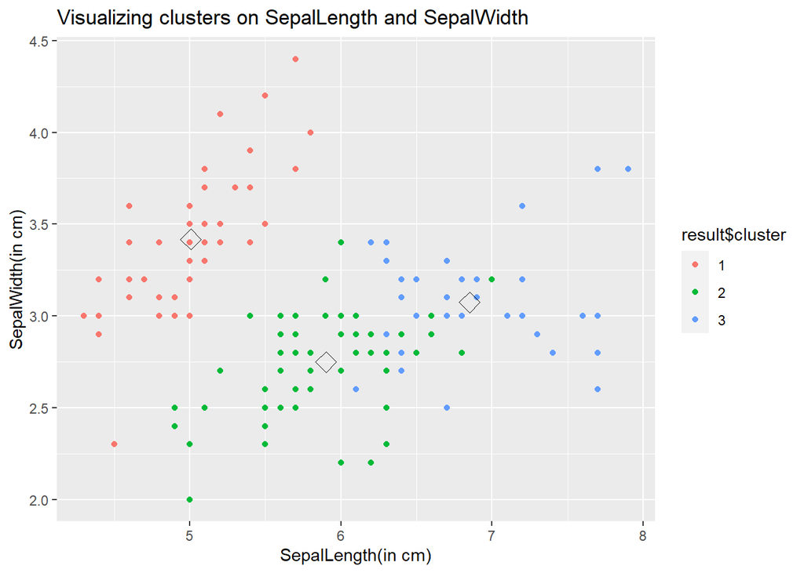

```r
ggplot(iris.s)+geom_point(aes(x=SepalLengthCm,y=SepalWidthCm,color=result$cluster))+geom_point(data=center,aes(x=SepalLengthCm,y=SepalWidthCm),shape=5,color="black",size=4)+labs(x="SepalLength(in cm)",y="SepalWidth(in cm)")+ggtitle("Visualizing clusters on SepalLength and SepalWidth")
```